# TProject 1 - U.S. College Data

Daniel Schlomer, Jesse Pye

Nov. 2, 2015

This is an html file that documents the steps to reproduce our project . This html file presents a visual story about our data and what we discovered about our data using visualization and workflow techniques.

The first thing we did was locate a source of data. We used college data from data.gov. This huge dataset had information for over 7000 U.S. Colleges, including information like average SAT scores, tuition, admission rates, and more.

For our first analysis, by comparing two measures, we created a scatter plot, comparing average SAT scores against admission rates. We also labled the outliers on this graph. The graph shows a clear correlation between SAT scores and admission rates.

First image:

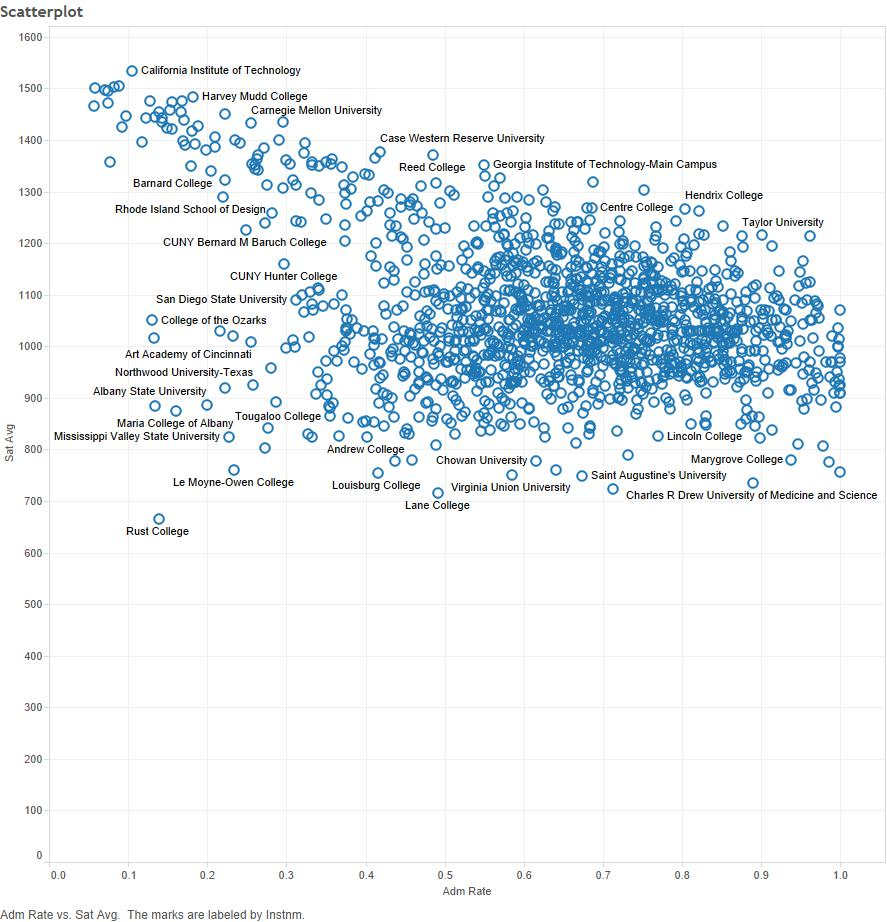

For our second analysis, we looked at the cost of persuing different degrees at schools with 20,000 students or more. In this bar chart, colleges are grouped according to the most popular degree type from that university and by their cost. “Low”" cost colleges cost less than $15,000/year, (including tuition, books, and living expenses), “medium” cost less than $30,000, and “high” cost more than $30,000. A reference line shows the median cost for each category.

Second image:

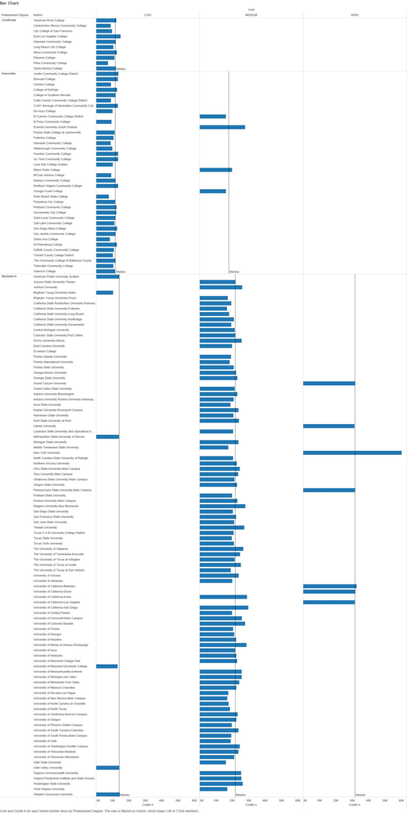

Our chart looks at the graduation rates of different types of schools. To form the crosstab, we used the governance type, total cost and school size as dimensions. Dividing the schools into these categories provided a look into how students perform at different types of schools. Our KPI is a measure of how many students graduate the college. If the class has a 50% graduation rate, they recieve a “PASS” rating. Otherwise they recieve a “FAIL” rating. This KPI is show using green and red numbers. For-profit colleges have the lowest graduation rates and never rise above the 50% mark. As schools get larger, they typically have higher graduation rates and have a great change of recieving a “PASS” rating. Third image:

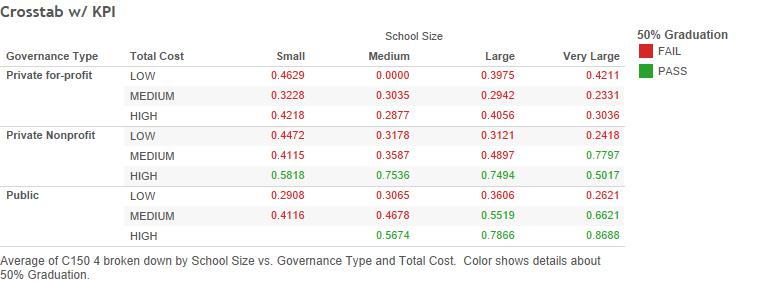